# Supervised Learning Classification Project: AllLife Bank Personal Loan Campaign

## Problem Statement

### Context

AllLife Bank is a US bank that has a growing customer base. The majority of these customers are liability customers (depositors) with varying sizes of deposits. The number of customers who are also borrowers (asset customers) is quite small, and the bank is interested in expanding this base rapidly to bring in more loan business and in the process, earn more through the interest on loans. In particular, the management wants to explore ways of converting its liability customers to personal loan customers (while retaining them as depositors).

A campaign that the bank ran last year for liability customers showed a healthy conversion rate of over 9% success. This has encouraged the retail marketing department to devise campaigns with better target marketing to increase the success ratio.

You as a Data scientist at AllLife bank have to build a model that will help the marketing department to identify the potential customers who have a higher probability of purchasing the loan.

### Objective

To predict whether a liability customer will buy personal loans, to understand which customer attributes are most significant in driving purchases, and identify which segment of customers to target more.

### Data Dictionary

- `ID`: Customer ID
- `Age`: Customer’s age in completed years
- `Experience`: #years of professional experience
- `Income`: Annual income of the customer (in thousand dollars)
- `ZIP Code`: Home Address ZIP code.
- `Family`: the Family size of the customer
- `CCAvg`: Average spending on credit cards per month (in thousand dollars)
- `Education`: Education Level. 1: Undergrad; 2: Graduate;3: Advanced/Professional
- `Mortgage`: Value of house mortgage if any. (in thousand dollars)
- `Personal_Loan`: Did this customer accept the personal loan offered in the last campaign? (0: No, 1: Yes)
- `Securities_Account`: Does the customer have securities account with the bank? (0: No, 1: Yes)
- `CD_Account`: Does the customer have a certificate of deposit (CD) account with the bank? (0: No, 1: Yes)
- `Online`: Do customers use internet banking facilities? (0: No, 1: Yes)
- `CreditCard`: Does the customer use a credit card issued by any other Bank (excluding All life Bank)? (0: No, 1: Yes)

## Importing necessary libraries

```python
import pandas as pd
import numpy as np
import seaborn as sns
import matplotlib.pyplot as plt
%matplotlib inline

from sklearn import metrics
from sklearn.model_selection import train_test_split
from sklearn.tree import DecisionTreeClassifier
from sklearn import tree
from sklearn.model_selection import GridSearchCV
```

## Loading the dataset

```python
df = pd.read_csv("Loan_Modeling.csv")

#Setting ZIP as a string so it's strictly categorical.
df['ZIPCode'] = df['ZIPCode'].astype(str)

df.head()
```

|  | ID | Age | Experience | Income | ZIPCode | Family | CCAvg | Education | Mortgage | Personal_Loan | Securities_Account | CD_Account | Online | CreditCard |
| --- | --- | --- | --- | --- | --- | --- | --- | --- | --- | --- | --- | --- | --- | --- |
| 0 | 1 | 25 | 1 | 49 | 91107 | 4 | 1.6 | 1 | 0 | 0 | 1 | 0 | 0 | 0 |
| 1 | 2 | 45 | 19 | 34 | 90089 | 3 | 1.5 | 1 | 0 | 0 | 1 | 0 | 0 | 0 |
| 2 | 3 | 39 | 15 | 11 | 94720 | 1 | 1.0 | 1 | 0 | 0 | 0 | 0 | 0 | 0 |
| 3 | 4 | 35 | 9 | 100 | 94112 | 1 | 2.7 | 2 | 0 | 0 | 0 | 0 | 0 | 0 |
| 4 | 5 | 35 | 8 | 45 | 91330 | 4 | 1.0 | 2 | 0 | 0 | 0 | 0 | 0 | 1 |

## Data Overview

### Basic Statistics

```python
#Look at basic statistics for all columns.
df.describe()
```

|  | ID | Age | Experience | Income | Family | CCAvg | Education | Mortgage | Personal_Loan | Securities_Account | CD_Account | Online | CreditCard |
| --- | --- | --- | --- | --- | --- | --- | --- | --- | --- | --- | --- | --- | --- |
| count | 5000.000000 | 5000.000000 | 5000.000000 | 5000.000000 | 5000.000000 | 5000.000000 | 5000.000000 | 5000.000000 | 5000.000000 | 5000.000000 | 5000.00000 | 5000.000000 | 5000.000000 |
| mean | 2500.500000 | 45.338400 | 20.104600 | 73.774200 | 2.396400 | 1.937938 | 1.881000 | 56.498800 | 0.096000 | 0.104400 | 0.06040 | 0.596800 | 0.294000 |
| std | 1443.520003 | 11.463166 | 11.467954 | 46.033729 | 1.147663 | 1.747659 | 0.839869 | 101.713802 | 0.294621 | 0.305809 | 0.23825 | 0.490589 | 0.455637 |
| min | 1.000000 | 23.000000 | -3.000000 | 8.000000 | 1.000000 | 0.000000 | 1.000000 | 0.000000 | 0.000000 | 0.000000 | 0.00000 | 0.000000 | 0.000000 |
| 25% | 1250.750000 | 35.000000 | 10.000000 | 39.000000 | 1.000000 | 0.700000 | 1.000000 | 0.000000 | 0.000000 | 0.000000 | 0.00000 | 0.000000 | 0.000000 |
| 50% | 2500.500000 | 45.000000 | 20.000000 | 64.000000 | 2.000000 | 1.500000 | 2.000000 | 0.000000 | 0.000000 | 0.000000 | 0.00000 | 1.000000 | 0.000000 |
| 75% | 3750.250000 | 55.000000 | 30.000000 | 98.000000 | 3.000000 | 2.500000 | 3.000000 | 101.000000 | 0.000000 | 0.000000 | 0.00000 | 1.000000 | 1.000000 |
| max | 5000.000000 | 67.000000 | 43.000000 | 224.000000 | 4.000000 | 10.000000 | 3.000000 | 635.000000 | 1.000000 | 1.000000 | 1.00000 | 1.000000 | 1.000000 |

- ID: Customer ID.
  - This is the index, going from 1 to 5000. That's how many users we have.
- Age: Customer’s age in completed years
  - Youngest is 23, oldest is 67. 45.3 on average. This is a pretty wide spread. I do expect this to correlate with the target goal, but I also suspect co-correlation with other features that would be even better. Will keep an eye on this.
- Experience: #years of professional experience
  - Directly related to age, and perhaps even more relevant. But the minimum is -3? What does that mean?
- Income: Annual income of the customer (in thousand dollars)
  - The mean is well above the median, so right-skewed. Could be meaningful for one branch of a decision tree, but only for a small portion of the input population.
- ZIP Code: Home Address ZIP code.
  - Not truly a numerical category, though they do all start with 9 meaning they're all on the US west coast. I'll check this out but I'm not expecting much.
- Family: the Family size of the customer
  - Smallest family is 1, largest is 4. That would be truly surprising that *none* exceed 4. This might matter.
- CCAvg: Average spending on credit cards per month (in thousand dollars)
  - Another right-skewed feature. Some of these are some high spenders (10k dollars a month?). I would expect many of these to also be the ones with high income, but perhaps not always.
- Education: Education Level. 1: Undergrad; 2: Graduate;3: Advanced/Professional
  - A categorical feature that I expect to be a strong predictor. All of these are at least undergrad.
- Mortgage: Value of house mortgage if any. (in thousand dollars) *
- Personal_Loan: Did this customer accept the personal loan offered in the last campaign?
  - This is the target variable. As stated in the prompt, over 9% of customers did accept the personal loan, and the goal is to classify the users most likely to accept a loan in a future campaign.
- Securities_Account: Does the customer have securities account with the bank?
  - This and all the remaining features are binary, so the mean of these categories is really the percentage of users who answer "yes" to the question. Only 10% have a securities account. Intuituion would suggest that already having plural accounts with the bank is probably well correlated with accepting the personal loan.
- CD_Account: Does the customer have a certificate of deposit (CD) account with the bank?
  - Only 6% of users already have a CD account with the bank.
- Online: Do customers use internet banking facilities?
  - 59.7% of users use banking facilities. Linked to age?
- CreditCard: Does the customer use a credit card issued by any other Bank (excluding All life Bank)?
  - 29.4% of users have a credit card with a different bank already. This competition could have customer's going elsewhere for their personal loans.

The only abnormality to me is are the lines with negative experience. Let's take a quick look at just those and guess what they mean.

```python
df[df['Experience'] < 0].head(15)
```

|  | ID | Age | Experience | Income | ZIPCode | Family | CCAvg | Education | Mortgage | Personal_Loan | Securities_Account | CD_Account | Online | CreditCard |
| --- | --- | --- | --- | --- | --- | --- | --- | --- | --- | --- | --- | --- | --- | --- |
| 89 | 90 | 25 | -1 | 113 | 94303 | 4 | 2.30 | 3 | 0 | 0 | 0 | 0 | 0 | 1 |
| 226 | 227 | 24 | -1 | 39 | 94085 | 2 | 1.70 | 2 | 0 | 0 | 0 | 0 | 0 | 0 |
| 315 | 316 | 24 | -2 | 51 | 90630 | 3 | 0.30 | 3 | 0 | 0 | 0 | 0 | 1 | 0 |
| 451 | 452 | 28 | -2 | 48 | 94132 | 2 | 1.75 | 3 | 89 | 0 | 0 | 0 | 1 | 0 |
| 524 | 525 | 24 | -1 | 75 | 93014 | 4 | 0.20 | 1 | 0 | 0 | 0 | 0 | 1 | 0 |
| 536 | 537 | 25 | -1 | 43 | 92173 | 3 | 2.40 | 2 | 176 | 0 | 0 | 0 | 1 | 0 |
| 540 | 541 | 25 | -1 | 109 | 94010 | 4 | 2.30 | 3 | 314 | 0 | 0 | 0 | 1 | 0 |
| 576 | 577 | 25 | -1 | 48 | 92870 | 3 | 0.30 | 3 | 0 | 0 | 0 | 0 | 0 | 1 |
| 583 | 584 | 24 | -1 | 38 | 95045 | 2 | 1.70 | 2 | 0 | 0 | 0 | 0 | 1 | 0 |
| 597 | 598 | 24 | -2 | 125 | 92835 | 2 | 7.20 | 1 | 0 | 0 | 1 | 0 | 0 | 1 |
| 649 | 650 | 25 | -1 | 82 | 92677 | 4 | 2.10 | 3 | 0 | 0 | 0 | 0 | 1 | 0 |
| 670 | 671 | 23 | -1 | 61 | 92374 | 4 | 2.60 | 1 | 239 | 0 | 0 | 0 | 1 | 0 |
| 686 | 687 | 24 | -1 | 38 | 92612 | 4 | 0.60 | 2 | 0 | 0 | 0 | 0 | 1 | 0 |
| 793 | 794 | 24 | -2 | 150 | 94720 | 2 | 2.00 | 1 | 0 | 0 | 0 | 0 | 1 | 0 |
| 889 | 890 | 24 | -2 | 82 | 91103 | 2 | 1.60 | 3 | 0 | 0 | 0 | 0 | 1 | 1 |

These are all young people, with no other obvious relationship that leaps out. Given the relationship between Age and Experience, I'll check that relationship visually.

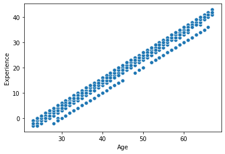

```python
sns.scatterplot(data=df, x='Age', y='Experience')
```

Huh.

Well, this is a pretty good indication that the data is synthetic. This correlation is too perfect. It seems like Experience = (Age above minimum) +/- (Random number), so whatever algorithm constructed this data might occasionally have "lowrolled" on both age and experience, bringing it negative. It doesn't actually mean anything, but ... we're gonna roll with it because it *could* be interpreted as "years before graduation of current program".

### Checking for nulls and data types.

```python
df.info()
```

```
<class 'pandas.core.frame.DataFrame'>
RangeIndex: 5000 entries, 0 to 4999
Data columns (total 14 columns):
 #   Column              Non-Null Count  Dtype
---  ------              --------------  -----
 0   ID                  5000 non-null   int64
 1   Age                 5000 non-null   int64
 2   Experience          5000 non-null   int64
 3   Income              5000 non-null   int64
 4   ZIPCode             5000 non-null   object
 5   Family              5000 non-null   int64
 6   CCAvg               5000 non-null   float64
 7   Education           5000 non-null   int64
 8   Mortgage            5000 non-null   int64
 9   Personal_Loan       5000 non-null   int64
 10  Securities_Account  5000 non-null   int64
 11  CD_Account          5000 non-null   int64
 12  Online              5000 non-null   int64
 13  CreditCard          5000 non-null   int64
dtypes: float64(1), int64(12), object(1)
memory usage: 547.0+ KB
```

The data-types all seem to be consistent with what you'd expect them to be. We could change the last four into booleans but there are advantages to keeping them as integers.

The non-null values is encouraging, and since all of these data-types are integers or floats we can actually trust them to be real numbers. (When working with strings you could have technically non-null values that say "No Value" or something, but we don't need to worry about that here).

## Exploratory Data Analysis.

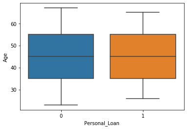

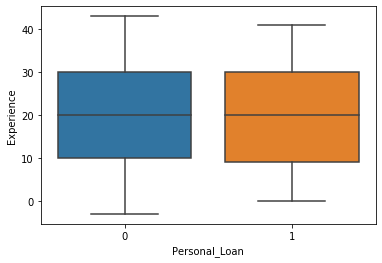

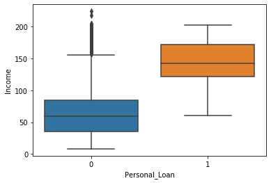

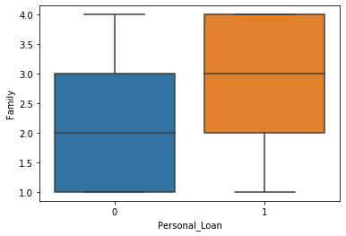

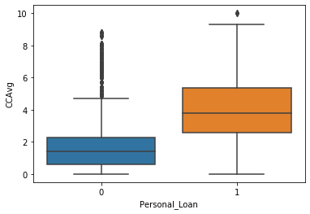

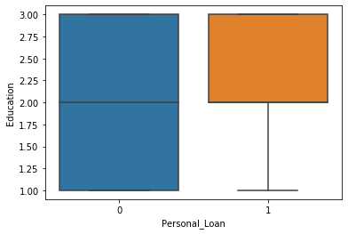

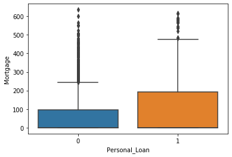

```python
# For each numerical feature, I'm going to look at its distribution but after separated by "Personal_Loan".
# In this way we can learn more about the features while also getting a sense of their effect on the target goal.
nums = ["Age", "Experience", "Income", "Family", "CCAvg", "Education", "Mortgage"]
for col in nums:
    sns.boxplot(x=df['Personal_Loan'], y=df[col])
    plt.show()
```

Some interesting results here!

First, the distributions of Age and Experience were nearly identical between those who did and didn't open a personal loan. It seems that this is not a useful indicator, against my presuppositions. I would also describe the two Mortgage distributions as similar but not identical.

Instead, the biggest differences came from Income and CCAvg, where those who accepted personal loans had much higher Income and CC spending overall - but not always. Those with high income and cc spending are outliers on the "no" side. Perhaps there's something else that separates them from those who did open loans.

Education and Family are harder to read because the spread of that data is very low. Education is only 1-3 and Family is only 1-4. There could be a strong correlation between them but these boxplots would not be very effective at showing it.

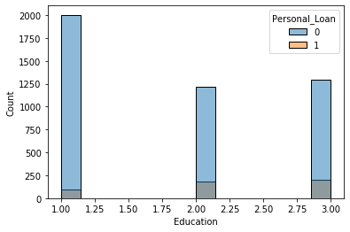

```python
sns.histplot(data=df, x='Education', hue='Personal_Loan')
```

This does show that the rate of acceptance is higher for Education levels 2 and 3. More acceptances in fewer cases.

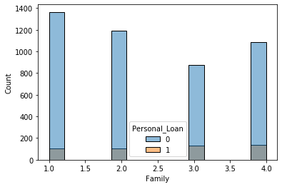

```python
sns.histplot(data=df, x='Family', hue='Personal_Loan')
```

There is less of a trend here. They all have close to equal acceptance values but the rates are different because family is not uniformly distributed.

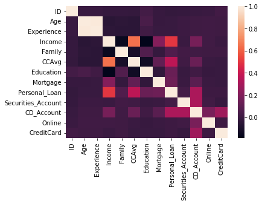

```python
#A correlation heat map can show what variables are associated with each other
sns.heatmap(df.corr())
```

Most of these are pretty cold correlations. Age and Experience is the one exception, and we've already discussed that.

There is some connection between Income and CCAvg, which makes sense because they're both related to the cash flow of the customer.

**Questions**:

1. What is the distribution of mortgage attribute? Are there any noticeable patterns or outliers in the distribution?
2. How many customers have credit cards?
3. What are the attributes that have a strong correlation with the target attribute (personal loan)?
4. How does a customer's interest in purchasing a loan vary with their age?
5. How does a customer's interest in purchasing a loan vary with their education?

#### 1. What is the distribution of mortgage attribute? Are there any noticeable patterns or outliers in the distribution?

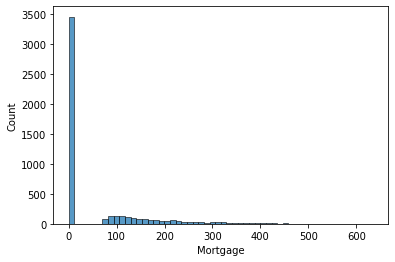

```python
sns.histplot(df['Mortgage'])
```

Nearly 70% of the values are just "0" which makes the rest of the distribution impossible to see. Let's look at the distribution of the ~1500 values above 0.

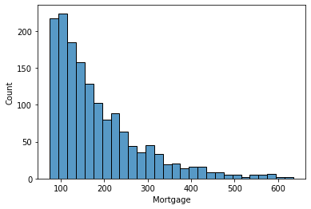

```python
# Filter out zero-values, then histplot again.
sns.histplot(df[df['Mortgage'] > 0]["Mortgage"])
```

Even with taking out the zeros, mortage is still very highly right-skewed. I do want to check if these are the same customers as those with high income.

```
1538 customers with mortgage.
```

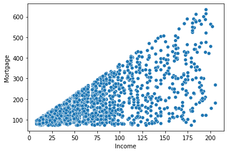

```python
df_mort = df[df['Mortgage']>0]
print(f"{df_mort.shape[0]} customers with mortgage.")
sns.scatterplot(data=df_mort, x="Income", y="Mortgage")
```

Ah, yes, this data is not very natural looking. There is a hard cap on how high a mortgage can go base on income, but the actual mortgage value is sort of random between that hard cap and ~$80k. This is a stronger correlation than the heat map showed before, mostly because a big percentage of customers from all income ranges simply don't have them.

#### 2. How many customers have credit cards?

```python
print(f"There are {df.loc[df['CCAvg']>0].shape[0]} customers who use credit cards.")
```

```
There are 4894 customers who use credit cards.
```

Note that this is the *minimum* number of customers who *have* credit cards. There may be more that have credit cards that just don't use them.

```python
print(f"There are {df.loc[df['CreditCard']==1].shape[0]} customers with credit cards from other banks.")
```

```
There are 1470 customers with credit cards from other banks.
```

This leaves *at least* 3,424 customers with credit cards exclusive to AllLife Bank. I'm actually going to add this as a category, since there is a chance that exclusivity in credit card usage could be related to willingness to take out a loan.

```python
df['ExclusiveCC'] = np.where((df["CCAvg"]>0) & (df["CreditCard"]==0), 1, 0)
df.head()
```

|  | ID | Age | Experience | Income | ZIPCode | Family | CCAvg | Education | Mortgage | Personal_Loan | Securities_Account | CD_Account | Online | CreditCard | ExclusiveCC |
| --- | --- | --- | --- | --- | --- | --- | --- | --- | --- | --- | --- | --- | --- | --- | --- |
| 0 | 1 | 25 | 1 | 49 | 91107 | 4 | 1.6 | 1 | 0 | 0 | 1 | 0 | 0 | 0 | 1 |
| 1 | 2 | 45 | 19 | 34 | 90089 | 3 | 1.5 | 1 | 0 | 0 | 1 | 0 | 0 | 0 | 1 |
| 2 | 3 | 39 | 15 | 11 | 94720 | 1 | 1.0 | 1 | 0 | 0 | 0 | 0 | 0 | 0 | 1 |
| 3 | 4 | 35 | 9 | 100 | 94112 | 1 | 2.7 | 2 | 0 | 0 | 0 | 0 | 0 | 0 | 1 |
| 4 | 5 | 35 | 8 | 45 | 91330 | 4 | 1.0 | 2 | 0 | 0 | 0 | 0 | 0 | 1 | 0 |

```python
#Count the number of customers who belong to the new category.
df.loc[df["ExclusiveCC"]==1].shape[0]
```

```
3452
```

As expected, the number isn't exactly 3,424. The difference is 28, so that must be the number of customers who didn't appear in the initial search as those who we know have a credit card but don't use them.

```python
#Filter for customers who do not use credit cards but have at least one credit card (with another bank).
df.loc[(df['CCAvg']==0) & (df['CreditCard']==1)].shape[0]
```

```
28
```

Yep, there they are. **Even now**, there could be more than 3,452, but we don't have a column that says "has CC with AllLife", so it's not possible to know how many more would fall into this category.

#### 3. What are the attributes that have a strong correlation with the target attribute (personal loan)?

```python
#Show simple correlation values for each feature against Personal Loan.
df.corr()['Personal_Loan']
```

```
ID                   -0.024801
Age                  -0.007726
Experience           -0.007413
Income                0.502462
Family                0.061367
CCAvg                 0.366889
Education             0.136722
Mortgage              0.142095
Personal_Loan         1.000000
Securities_Account    0.021954
CD_Account            0.316355
Online                0.006278
CreditCard            0.002802
ExclusiveCC           0.006767
Name: Personal_Loan, dtype: float64
```

The highest R-scores belong to Income, CCAvg, and CD_Account, but the same problem in the earlier split boxplots exists here as well: Education and Family just don't span very far. If the correlation is anything less than perfect, it will not shine clearly here. We are going to need to use more discriminative methods that's more sensitive to near-categorical values, such as a decision tree (coming up!).

#### 4. How does a customer's interest in purchasing a loan vary with their age?

From the previous question, the correlation between Age and Personal_Loan is fairly low. But we can visually confirm this by binning the data by age and graph the personal loan acceptance rate for each bin.

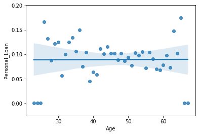

```python
df_gb_age = df.groupby(["Age"]).mean().reset_index()
sns.regplot(data=df_gb_age, x="Age", y="Personal_Loan")
```

This is indeed a weak correlation. The regplot shows an almost perfectly horizontal regression line, suggesting there is actually no relationship at all.

#### 5. How does a customer's interest in purchasing a loan vary with their education?

Let's repeat the same process on Education, but there are only 3 values so there will only be 3 dots.

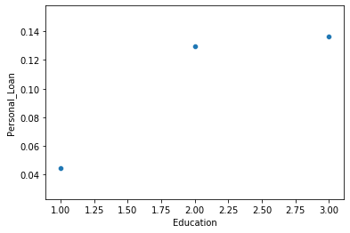

```python
df_gb_ed = df.groupby(["Education"]).mean().reset_index()
sns.scatterplot(data=df_gb_ed, x="Education", y="Personal_Loan")
```

This is more promising. It seems that only having undergraduate education (class 1) makes you significantly less likely to have accepted a loan compared to having a graduate or advanced degree (2 and 3). This is the kind of relationship that would be captured well in a decision tree.

## Data pre-processing

We've already shown that the data has no missing values and that there are no egregious outliers. An additional feature has been added to potentially be an important feature. We're ready for data modeling!

## Model Building

### Model Evaluation Criterion

I am going to be using a Decision Tree Classifier for the following reasons:

- We need a supervised model since we're trying to classify a target variable.
- It works well with a categorical output (yes or no) and multiple types of input.
- The results are intuitive to understand and the model is easy improve.

We will split the data into training and testing sets. A successful model will be able to correctly classify the 0s and 1s of the Personal Loan column given all the other features. There are two types of errors it can create:

- Someone offered a personal loan who will refuse.
- Someone *not* offered a personal loan who would accept.

There is little cost in offering a loan that falls through. The greater loss would be the missed opportunity for a potential customer that is not offered a loan. In essence, since false negatives are more costly, we prioritize **recall** as our performance metric (higher recall corresponds to fewer false negatives). We are not as worried about false positives.

### Model Building

```python
# X (input) is every feature except for the target variable
X = df.drop("Personal_Loan", axis=1).drop("ID", axis=1)
features = list(X.columns)

# y (output) is the target variable
y = df["Personal_Loan"]
```

```python
X_train, X_test, y_train, y_test = train_test_split(X, y, test_size=.3, random_state=1)
```

```python
def DecisionTreeProcess(max_depth=None, ccp_alpha=0, verbose=True):
    #Create a decision tree with customizations and report the quickly relevant statistics.
    TREE = DecisionTreeClassifier(criterion='gini', max_depth=max_depth, ccp_alpha=ccp_alpha, random_state=1)
    TREE.fit(X_train, y_train)

    y_predict = TREE.predict(X_test)
    recall = metrics.recall_score(y_test, y_predict)

    if verbose:
        print(f"Accuracy on training set : {TREE.score(X_train, y_train):.1%}")
        print(f"Accuracy on test set : {TREE.score(X_test, y_test):.1%}")
        print(f"Recall on test set : {recall:.1%}")

    return TREE, y_predict

def make_confusion_matrix(model, y_actual , labels=[0, 1]):
    #Make a nice looking heatmap of the confusion matrix, showing the number of true/false positives/negatives.
    #Especially useful to see the rates of false positives and false negatives against each other.

    y_predict = model.predict(X_test)
    cm=metrics.confusion_matrix( y_actual, y_predict, labels=labels)
    df_cm = pd.DataFrame(cm, index = [i for i in ["Actual - No","Actual - Yes"]],
                  columns = [i for i in ['Predicted - No','Predicted - Yes']])
    group_counts = ["{0:0.0f}".format(value) for value in
                cm.flatten()]
    group_percentages = ["{0:.2%}".format(value) for value in
                         cm.flatten()/np.sum(cm)]
    labels = [f"{v1}\n{v2}" for v1, v2 in
              zip(group_counts,group_percentages)]
    labels = np.asarray(labels).reshape(2,2)
    plt.figure(figsize = (10,7))
    sns.heatmap(df_cm, annot=labels,fmt='')
    plt.ylabel('True label')
    plt.xlabel('Predicted label')

def getRecall(model):
    return metrics.recall_score(y_test, model.predict(X_test))

def getAccuracy(model):
    return metrics.accuracy_score(y_test, model.predict(X_test))
```

```python
TREE, y_predict = DecisionTreeProcess()
print(f"Depth: {TREE.get_depth()}")
```

```
Accuracy on training set : 100.0%
Accuracy on test set : 97.9%
Recall on test set : 87.9%
Depth: 11
```

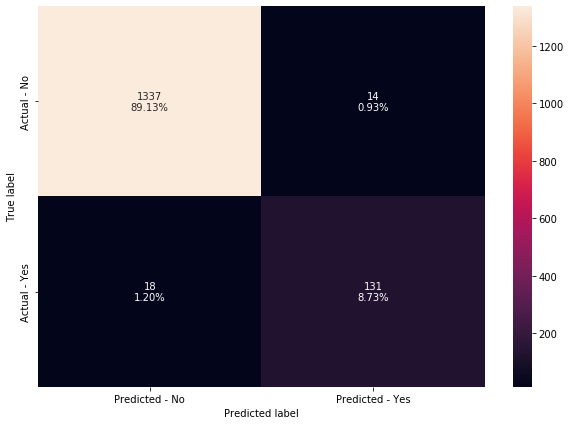

```python
make_confusion_matrix(TREE, y_test)
```

Before we get too excited, let's look at the visualization of our tree.

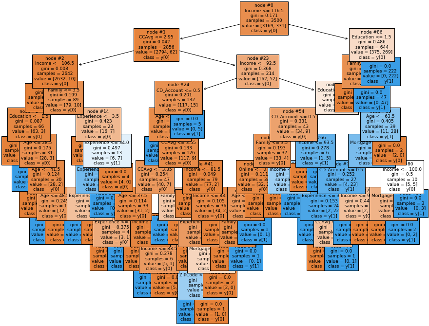

```python
plt.figure(figsize=(15,12))
tree.plot_tree(TREE,feature_names=features,filled=True,fontsize=9,node_ids=True,class_names=True)
plt.show()
```

Overall, while 97.9% accuracy on the test set seems great, there is room for improvement. Firstly, our tree is too large. The final nodes of the tree only have a few samples each -- allowing a tree to run its full depth and have tiny mono-cultures is guaranteed to overfit your data. Futhermore, our recall score is 87.9%, which means we missed 12.1% of the customers that we might have had. Our model is perhaps too conservative. For the purposes of this problem, we don't mind sacrificing a little bit of accuracy to enhance our recall.

However, there is still much to learn from this. Before I try to adjust the model, I want to see which features were identified as the most impactful by the model.

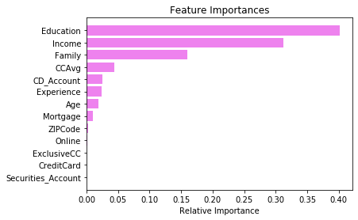

```python
importances = TREE.feature_importances_
indices = np.argsort(importances)

plt.title('Feature Importances')
plt.barh(range(len(indices)), importances[indices], color='violet', align='center')
plt.yticks(range(len(indices)), [features[i] for i in indices])
plt.xlabel('Relative Importance')
plt.show()
```

Oh!

As I guessed, a simple correlation value was not sufficient for the two near-categorical features of Education and Family. This Decision Tree found that those were both top-3 features in determining class. On the other hand, the new category ExclusiveCC was not important at all.

This helps me to estimate how many nodes we might need for the optimized tree.

### Model Performance Improvement

#### Pre-pruning

The feature importances chart showed that the top four features were Education, Income, Family, and CCAvg, in that order. We also know that Income and CCAvg are already highly correlated, so my initial guess is that the best max depth is going to be close to 3, but we can try a bunch of ranges.

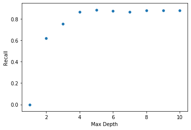

```python
#Try all depths between 1 and 10 (the original tree had 11)
depths = np.arange(1,11)

#For each value of depth, make a decision tree up to that depth and calculate its performance (recall)
recalls = []
trees = [""]  #This array will store the trees where trees[n] is the tree with a max depth n.
for d in depths:
    tr, y_p = DecisionTreeProcess(max_depth=d, verbose=False)
    trees.append(tr)
    recalls.append(metrics.recall_score(y_test, y_p))

#Plot the depths vs. recall performance
sns.scatterplot(x=depths, y=recalls)
plt.xlabel("Max Depth")
plt.ylabel("Recall")
plt.show()
```

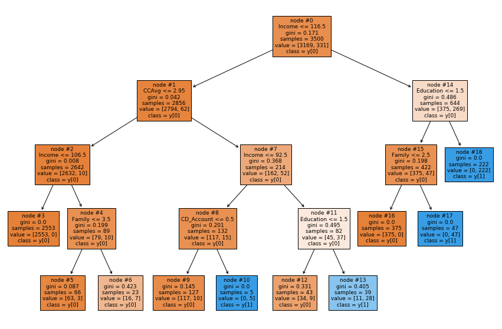

```python
#Visualizatin of Trees-4, with a max depth of 4.

preprune_tree = trees[4]
plt.figure(figsize=(15,10))
tree.plot_tree(preprune_tree,feature_names=features, filled=True, fontsize=9, node_ids=True, class_names=True)
plt.show()
```

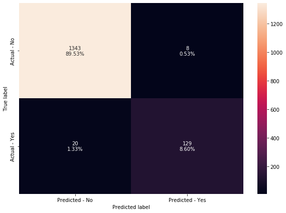

```python
make_confusion_matrix(preprune_tree, y_test)
```

```python
print(f"Recall: {metrics.recall_score(y_test, preprune_tree.predict(X_test)):.1%}")
```

```
Recall: 86.6%
```

While the tree is simpler, our recall went down as well. Adjusting max_depth didn't really result in a better model.

#### Post-pruning

Another method is to take the whole tree and cut off nodes that don't add value, instead of specifiying in advance how many nodes we want. We can accomplish this by varying the cost-complexity alpha values. Alpha can be thought of as a sliding scale of allowed impurity in a node, where alpha=0 means zero pruning. By slowly raising alpha and evaluating changes in the tree's performance, we might find an optimized value. We want to find the lowest alpha that still has good performance.

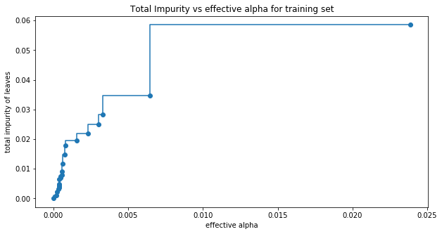

```python
#The path shows the increasing alpha/impurity values we are willing to accept as we remove nodes.
path = TREE.cost_complexity_pruning_path(X_train, y_train)
ccp_alphas, impurities = path.ccp_alphas, path.impurities

#This chart shows the increase in alpha/impurty for each node that we remove.
fig, ax = plt.subplots(figsize=(10,5))
ax.plot(ccp_alphas[:-1], impurities[:-1], marker='o', drawstyle="steps-pre")
ax.set_xlabel("effective alpha")
ax.set_ylabel("total impurity of leaves")
ax.set_title("Total Impurity vs effective alpha for training set")
plt.show()
```

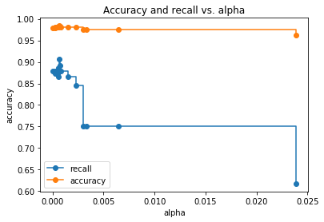

```python
#For each alpha value, show the resulting decision tree and calculate its performance (recall/accuracy)
recalls = []
accuracies = []
trees = []
for ccp_alpha in ccp_alphas[:-1]:
    a_tree = DecisionTreeClassifier(random_state=1, ccp_alpha=ccp_alpha)
    a_tree.fit(X_train, y_train)
    trees.append(a_tree)

recalls = [metrics.recall_score(y_test, a_tree.predict(X_test)) for a_tree in trees]
accuracies = [metrics.accuracy_score(y_test, a_tree.predict(X_test)) for a_tree in trees]

#Plot the recall/accuracy based on the alpha we're using.
fig, ax = plt.subplots()
ax.set_xlabel("alpha")
ax.set_ylabel("accuracy")
ax.set_title("Accuracy and recall vs. alpha")
ax.plot(ccp_alphas[:-1], recalls, marker="o", label="recall", drawstyle="steps-post")
ax.plot(ccp_alphas[:-1], accuracies, marker="o", label="accuracy", drawstyle="steps-post")
ax.legend()
plt.show()
```

Let's pick the model with the highest recall.

```python
perf_df = pd.DataFrame({
    "ccp_alphas":ccp_alphas[:-1],
    "recalls": recalls,
    "accuracies": accuracies
})
perf_df
```

|  | ccp_alphas | recalls | accuracies |
| --- | --- | --- | --- |
| 0 | 0.000000 | 0.879195 | 0.978667 |
| 1 | 0.000223 | 0.879195 | 0.979333 |
| 2 | 0.000268 | 0.872483 | 0.980000 |
| 3 | 0.000359 | 0.872483 | 0.980667 |
| 4 | 0.000381 | 0.872483 | 0.980667 |
| 5 | 0.000381 | 0.872483 | 0.980667 |
| 6 | 0.000381 | 0.872483 | 0.980667 |
| 7 | 0.000381 | 0.872483 | 0.980667 |
| 8 | 0.000409 | 0.872483 | 0.981333 |
| 9 | 0.000476 | 0.872483 | 0.981333 |
| 10 | 0.000508 | 0.872483 | 0.981333 |
| 11 | 0.000582 | 0.865772 | 0.980667 |
| 12 | 0.000593 | 0.885906 | 0.982000 |
| 13 | 0.000641 | 0.906040 | 0.984000 |
| 14 | 0.000769 | 0.892617 | 0.982667 |
| 15 | 0.000792 | 0.879195 | 0.981333 |
| 16 | 0.001552 | 0.865772 | 0.981333 |
| 17 | 0.002333 | 0.845638 | 0.980000 |
| 18 | 0.003024 | 0.751678 | 0.975333 |
| 19 | 0.003294 | 0.751678 | 0.975333 |
| 20 | 0.006473 | 0.751678 | 0.975333 |
| 21 | 0.023866 | 0.617450 | 0.962000 |

We can see that the best value for ccp_alpha is 0.000641, which gives a recall of 90.6%. Let's analyze that tree.

```python
best_idx = perf_df["recalls"].idxmax()
postprune_tree = trees[best_idx]
```

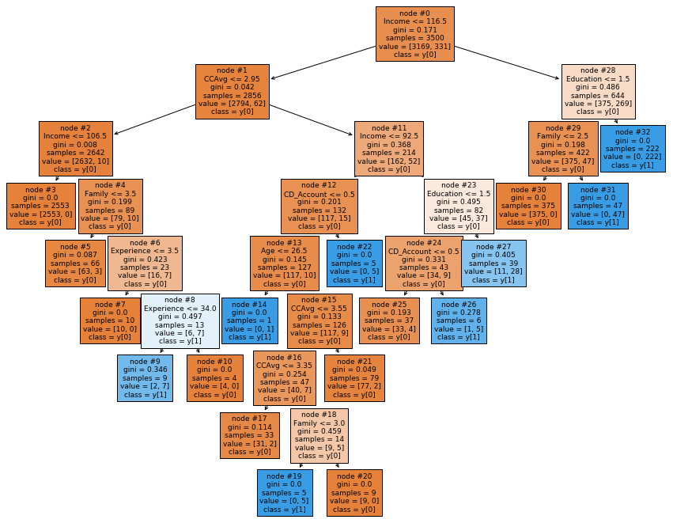

```python
plt.figure(figsize=(15,12))
tree.plot_tree(postprune_tree,feature_names=features,filled=True,fontsize=9,node_ids=True,class_names=True)
plt.show()
```

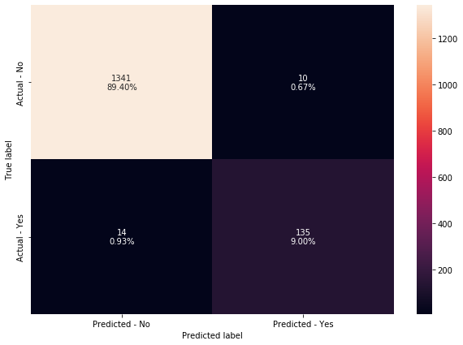

```python
make_confusion_matrix(postprune_tree, y_test)
```

This tree is a little deeper than our pre-pruned tree, but not by too much. The values on the confusion matrix are slightly better than what we've seen before, with 9% "hits" and only 0.93% "misses".

## Model Comparison and Final Model Selection

Let's show the models we got from each process and compare them in recall and accuracy.

```python
comparison = pd.DataFrame({
    "model": ["Full Decision Tree", "Max Depth 4", "CCPA 0.000641"],
    "recall": [getRecall(TREE), getRecall(preprune_tree), getRecall(postprune_tree)],
    "accuracy": [getAccuracy(TREE), getAccuracy(preprune_tree), getAccuracy(postprune_tree)]
})
comparison
```

|  | model | recall | accuracy |
| --- | --- | --- | --- |
| 0 | Full Decision Tree | 0.879195 | 0.978667 |
| 1 | Max Depth 4 | 0.865772 | 0.981333 |
| 2 | CCPA 0.000641 | 0.906040 | 0.984000 |

In this case, the post-pruning process by finding the optimal cost-complexity parameter resulted in the best performance. It is also less overfit than the full decision tree, despite being less complex.

## Clustering

Even though we have a fairly accurate decision tree, I'm curious about clustering. I'm going to try applying KMeans clustering to our original dataframe without designating Personal_Loan as a target variable. It may work out that certain clusters have higher personal loan rates and give more insight into the attributes that people who accept personal loans might have.

```python
#We need to normalize the values so no column becomes dominant mathematically. I am leaving the binary values alone.
kdf = df.copy().drop("ID", axis=1).drop("ZIPCode", axis=1)
normalize = ["Age", "Experience", "Income", "Family", "CCAvg", "Education", "Mortgage"]
for col in normalize:
    kdf[col] = (kdf[col] - kdf[col].mean())/(kdf[col].std())
kdf.head(10)
```

|  | Age | Experience | Income | Family | CCAvg | Education | Mortgage | Personal_Loan | Securities_Account | CD_Account | Online | CreditCard | ExclusiveCC |
| --- | --- | --- | --- | --- | --- | --- | --- | --- | --- | --- | --- | --- | --- |
| 0 | -1.774239 | -1.665912 | -0.538175 | 1.397274 | -0.193366 | -1.048973 | -0.555468 | 0 | 1 | 0 | 0 | 0 | 1 |
| 1 | -0.029521 | -0.096321 | -0.864023 | 0.525938 | -0.250586 | -1.048973 | -0.555468 | 0 | 1 | 0 | 0 | 0 | 1 |
| 2 | -0.552936 | -0.445119 | -1.363657 | -1.216733 | -0.536683 | -1.048973 | -0.555468 | 0 | 0 | 0 | 0 | 0 | 1 |
| 3 | -0.901880 | -0.968316 | 0.569708 | -1.216733 | 0.436047 | 0.141689 | -0.555468 | 0 | 0 | 0 | 0 | 0 | 1 |
| 4 | -0.901880 | -1.055515 | -0.625068 | 1.397274 | -0.536683 | 0.141689 | -0.555468 | 0 | 0 | 0 | 0 | 1 | 0 |
| 5 | -0.727408 | -0.619518 | -0.972639 | 1.397274 | -0.879999 | 0.141689 | 0.968415 | 0 | 0 | 0 | 1 | 0 | 1 |
| 6 | 0.668367 | 0.601276 | -0.038541 | -0.345398 | -0.250586 | 0.141689 | -0.555468 | 0 | 0 | 0 | 1 | 0 | 1 |
| 7 | 0.406659 | 0.339677 | -1.124701 | -1.216733 | -0.937218 | 1.332351 | -0.555468 | 0 | 0 | 0 | 0 | 1 | 0 |
| 8 | -0.901880 | -0.881116 | 0.156968 | 0.525938 | -0.765560 | 0.141689 | 0.467008 | 0 | 0 | 0 | 1 | 0 | 1 |
| 9 | -0.989116 | -0.968316 | 2.307565 | -1.216733 | 3.983650 | 1.332351 | -0.555468 | 1 | 0 | 0 | 0 | 0 | 1 |

```python
from sklearn.cluster import KMeans
from sklearn.metrics import silhouette_score
from scipy.spatial.distance import cdist
clusters=range(2,15)

sils = []
dists = []

#Attempt KMeans clustering with different numbers of clusters, from 1 to 15.
#We will store the silhouette scores and average to-cluster-center-distances for each model.
for k in clusters:
    model=KMeans(n_clusters=k)
    model.fit(kdf)
    labels = model.labels_
    sils.append(silhouette_score(kdf, labels, metric='euclidean'))
    dists.append(sum(np.min(cdist(kdf, model.cluster_centers_, 'euclidean'), axis=1)) / kdf.shape[0])
```

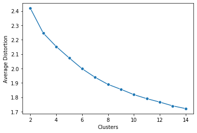

```python
sns.lineplot(x=clusters, y=dists, marker='o')
plt.xlabel("Clusters")
plt.ylabel("Average Distortion")
```

The distortion is the Euclidian distance from a point to its cluster's center. The average distortion goes down with more clusters because you can capture tighter groups if you need fewer points per group. The "elbow method" is one way to determine the best number of clusters to use by visually determining at which point adding more clusters doesn't decrease distortions as much. This graph is difficult to parse out, though. Perhaps there's a kink in the line at 10 clusters?

My initial reaction is that 10 would be good because we know that about 9%, or sorta close to 1-in-10, accepted the personal loan. We need about that level of resolution for the clusters to be sensitive to personal loan acceptance. However, with more ambiguous cases such as this, there is also a more mathematical way to determine it. The silhouette score is a comparison of the distances of each point within a cluster vs. the distances of each cluster. Higher silhouette scores correspond to more "natural" clustering, and it's reasonable to choose the number k that maximizes this score.

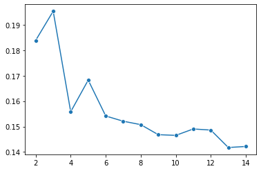

```python
sns.lineplot(x=clusters, y=sils, marker='o')
```

```python
#Create the 10-cluster model and attach the results to the original dataframe.
model=KMeans(n_clusters=10)
model.fit(kdf)
df['GROUP'] = model.predict(kdf)
```

```python
#What are the average values for each feature when separated by group?
df.groupby("GROUP").mean()
```

| GROUP | ID | Age | Experience | Income | Family | CCAvg | Education | Mortgage | Personal_Loan | Securities_Account | CD_Account | Online | CreditCard | ExclusiveCC |
| --- | --- | --- | --- | --- | --- | --- | --- | --- | --- | --- | --- | --- | --- | --- |
| 0 | 2502.413854 | 37.829485 | 12.936057 | 80.957371 | 1.513321 | 1.456590 | 1.097691 | 31.849023 | 0.037300 | 0.097691 | 0.044405 | 0.611012 | 0.314387 | 0.639432 |
| 1 | 2452.823529 | 55.527629 | 30.655971 | 44.474153 | 2.673797 | 1.099394 | 1.000000 | 42.376114 | 0.005348 | 0.101604 | 0.044563 | 0.600713 | 0.333333 | 0.650624 |
| 2 | 2428.710714 | 32.671429 | 7.592857 | 54.180357 | 3.642857 | 1.363839 | 1.408929 | 49.496429 | 0.030357 | 0.117857 | 0.037500 | 0.601786 | 0.269643 | 0.723214 |
| 3 | 2518.964615 | 55.081538 | 29.620000 | 51.653846 | 1.413846 | 1.296908 | 2.640000 | 42.396923 | 0.023077 | 0.090769 | 0.021538 | 0.590769 | 0.290769 | 0.676923 |
| 4 | 2522.847059 | 38.201961 | 12.570588 | 64.298039 | 3.545098 | 1.507804 | 2.698039 | 34.621569 | 0.086275 | 0.094118 | 0.047059 | 0.574510 | 0.272549 | 0.713725 |
| 5 | 2426.050420 | 38.392157 | 13.470588 | 152.098039 | 1.834734 | 5.944286 | 1.397759 | 26.030812 | 0.330532 | 0.109244 | 0.131653 | 0.588235 | 0.280112 | 0.719888 |
| 6 | 2620.952381 | 35.226667 | 9.836190 | 48.167619 | 1.443810 | 1.387829 | 2.619048 | 40.866667 | 0.034286 | 0.108571 | 0.047619 | 0.554286 | 0.302857 | 0.683810 |
| 7 | 2520.895765 | 44.951140 | 19.775244 | 132.156352 | 2.081433 | 3.205765 | 1.657980 | 343.491857 | 0.358306 | 0.094463 | 0.166124 | 0.596091 | 0.286645 | 0.703583 |
| 8 | 2425.105978 | 56.505435 | 31.402174 | 134.752717 | 1.894022 | 3.348234 | 1.407609 | 18.456522 | 0.326087 | 0.122283 | 0.125000 | 0.627717 | 0.290761 | 0.709239 |
| 9 | 2546.070117 | 56.539232 | 30.928214 | 53.232053 | 3.529215 | 1.352437 | 2.410684 | 41.510851 | 0.023372 | 0.111853 | 0.040067 | 0.624374 | 0.288815 | 0.709516 |

## Actionable Insights and Business Recommendations

The highest performing model is the Decision Tree with the optimized alpha value, from post-pruning. We can choose this tree to look at which features are the most important.

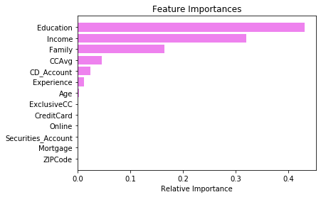

```python
importances = postprune_tree.feature_importances_
indices = np.argsort(importances)

plt.title('Feature Importances')
plt.barh(range(len(indices)), importances[indices], color='violet', align='center')
plt.yticks(range(len(indices)), [features[i] for i in indices])
plt.xlabel('Relative Importance')
plt.show()
```

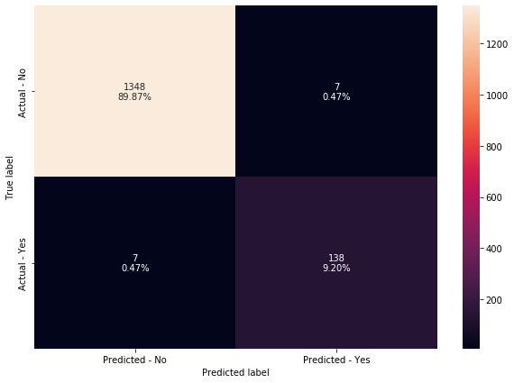

```python
make_confusion_matrix(postprune_tree, y_predict)
```

```python
print(tree.export_text(postprune_tree,feature_names=features,show_weights=True))
```

```
|--- Income <= 116.50
|   |--- CCAvg <= 2.95
|   |   |--- Income <= 106.50
|   |   |   |--- weights: [2553.00, 0.00] class: 0
|   |   |--- Income >  106.50
|   |   |   |--- Family <= 3.50
|   |   |   |   |--- weights: [63.00, 3.00] class: 0
|   |   |   |--- Family >  3.50
|   |   |   |   |--- Experience <= 3.50
|   |   |   |   |   |--- weights: [10.00, 0.00] class: 0
|   |   |   |   |--- Experience >  3.50
|   |   |   |   |   |--- Experience <= 34.00
|   |   |   |   |   |   |--- weights: [2.00, 7.00] class: 1
|   |   |   |   |   |--- Experience >  34.00
|   |   |   |   |   |   |--- weights: [4.00, 0.00] class: 0
|   |--- CCAvg >  2.95
|   |   |--- Income <= 92.50
|   |   |   |--- CD_Account <= 0.50
|   |   |   |   |--- Age <= 26.50
|   |   |   |   |   |--- weights: [0.00, 1.00] class: 1
|   |   |   |   |--- Age >  26.50
|   |   |   |   |   |--- CCAvg <= 3.55
|   |   |   |   |   |   |--- CCAvg <= 3.35
|   |   |   |   |   |   |   |--- weights: [31.00, 2.00] class: 0
|   |   |   |   |   |   |--- CCAvg >  3.35
|   |   |   |   |   |   |   |--- Family <= 3.00
|   |   |   |   |   |   |   |   |--- weights: [0.00, 5.00] class: 1
|   |   |   |   |   |   |   |--- Family >  3.00
|   |   |   |   |   |   |   |   |--- weights: [9.00, 0.00] class: 0
|   |   |   |   |   |--- CCAvg >  3.55
|   |   |   |   |   |   |--- weights: [77.00, 2.00] class: 0
|   |   |   |--- CD_Account >  0.50
|   |   |   |   |--- weights: [0.00, 5.00] class: 1
|   |   |--- Income >  92.50
|   |   |   |--- Education <= 1.50
|   |   |   |   |--- CD_Account <= 0.50
|   |   |   |   |   |--- weights: [33.00, 4.00] class: 0
|   |   |   |   |--- CD_Account >  0.50
|   |   |   |   |   |--- weights: [1.00, 5.00] class: 1
|   |   |   |--- Education >  1.50
|   |   |   |   |--- weights: [11.00, 28.00] class: 1
|--- Income >  116.50
|   |--- Education <= 1.50
|   |   |--- Family <= 2.50
|   |   |   |--- weights: [375.00, 0.00] class: 0
|   |   |--- Family >  2.50
|   |   |   |--- weights: [0.00, 47.00] class: 1
|   |--- Education >  1.50
|   |   |--- weights: [0.00, 222.00] class: 1
```

The other biggest chunks are the ones with very low acceptance rates. One of the first lines is "weights: [2553.00, 0.00] class: 0". This is a whopping 2553 people from whom no one accepted a personal loan. The features that define this cluster are "lower" income (less than 106.50k dollars) and low credit card spending (less than $2950/month).

Looking at the rest of them, most of these nodes are pretty small. There are 5 people with low income, high cc spending, higher age, and a small family that all accepted loans. But 9 customers with the same attributes except for having larger families instead rejected personal loans.

I said earlier that the cost of offering a loan is low, and that statement requires review. If I am an agent of the bank, and I have 10 meetings in a day with potential customers, and I only close on one loan, is that a success? It would take me 500 days or 100 agents 5 days to go through 5000 customers and would only close on (from this dataset) 480 loans.

My initial instinct that we should cast a wide net might be incorrect. For this reason, with everything being taken into account, I believe it's in the best interest of the bank to follow the decision tree model set out here and offer loans to those classified by the model to likely accept them.